# ACP avec noyau

4 avril 2018

## Plan

- Motivation
- Fonction noyau
- ACP avec noyau
- Application pratique
- Discussion

## Motivation

- L'ACP reduit la dimentionnalite tout en conservant le maximum de variance dans les données.
- Premières composante les plus informatives.
- Information non linéaire pas facile à capturer

## Exemple

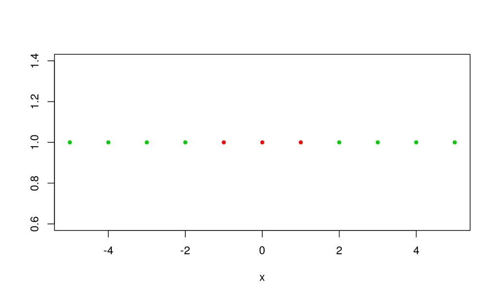

## Exemple

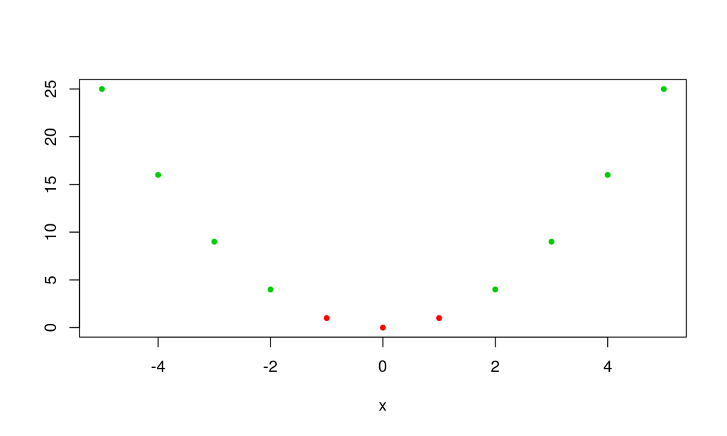

## Exemple

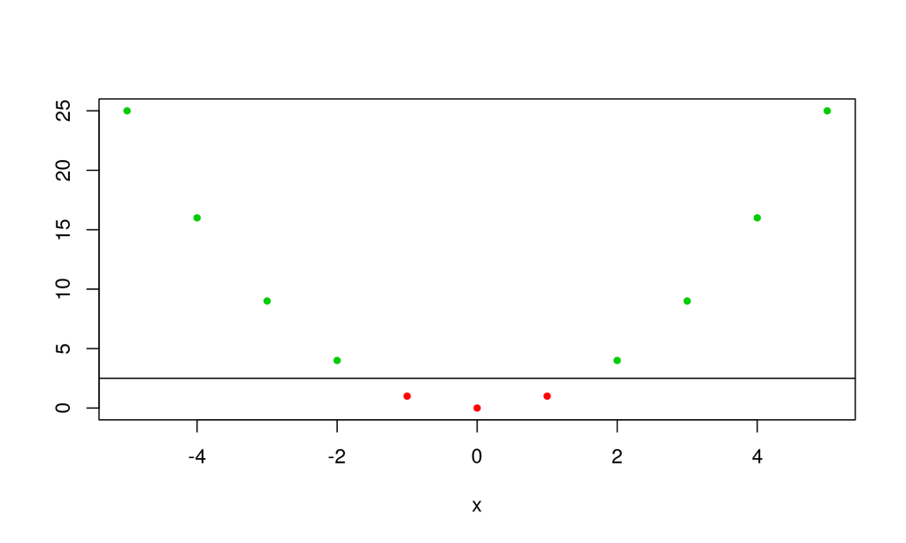

## Autre exemple

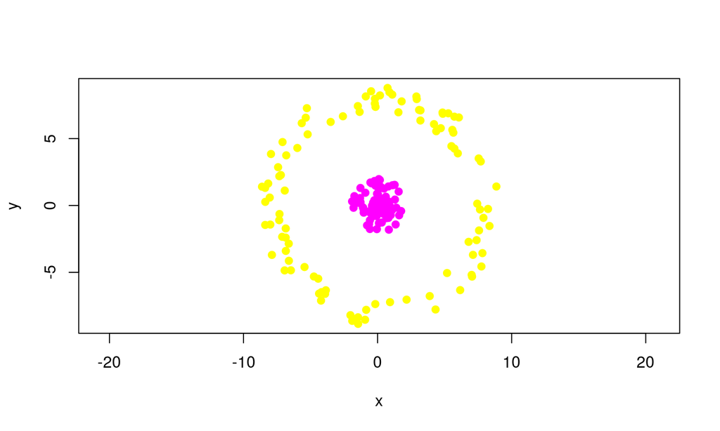

## Autre exemple

Soit la transformation

\[\Phi(\textbf{x}) = (x^2, \sqrt{2}xy, y^2).\] En appliquant cette transformation sur les données originales, on obtient un problème linéaire.

## Autre exemple

[interactive chart not shown]

## Autre exemple

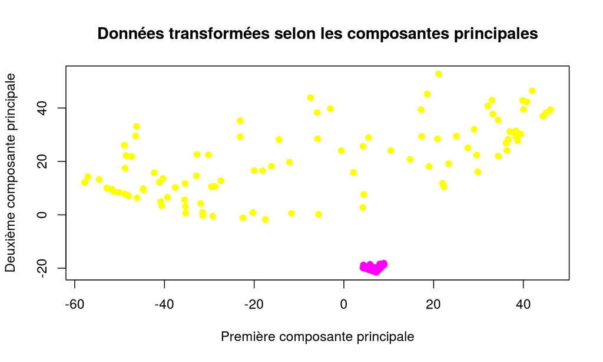

## Projection dans un autre espace d'attributs

-En général, on projète les données \(\textbf{x}\) dans un espace d'attributs par une transformation non linéaire.

-Formellement, on a

\[ \begin{aligned} \Phi: \mathbb{R}^N &\to \mathcal{F}\\ \textbf{x} &\mapsto \Phi(\textbf{x}) \end{aligned} \]

- Cette technique est utilisée dans le contexte des SVM.
- Au lieu de faire l'apprentissage statistique sur \(\textbf{x}_1, \textbf{x}_2, \dots, \textbf{x}_N\), on le fait sur \(\Phi(\textbf{x}_1), \Phi(\textbf{x}_2), \dots, \Phi(\textbf{x}_N)\).

## Rappel de l'ACP

Mathématiquement, les composantes principales sont obtenues selon une décomposition par valeurs et vecteurs propres de la matrice de covariances

\[ \frac{1}{N} \sum_{i = 1}^{N} \textbf{x}_i\textbf{x}_i^T.\] Correspond à la meilleure projection des données dans une dimension réduite.

## ACP avec noyau

On applique une ACP sur les données projetées (Schölkopf, Smola, and Müller 1997). On décompose la matrice de covariances de la matrice des transformations non linéaires

\[ \frac{1}{N} \sum_{i = 1}^{N} \Phi(\textbf{x}_i)\Phi(\textbf{x}_i)^T = \frac{1}{N} \sum_{i = 1}^{N} \Phi(\textbf{x}_i)\cdot \Phi(\textbf{x}_i).\]

## Exemple de transformation

Pour une données à deux attributs \(\textrm{x} = (x_1, x_2)\), on applique la transformation \(\Phi(\textbf{x}) = (x_1^2, \sqrt{2}x_1x_2, x_2^2)\). Le produit scalaire devient

\[ \begin{aligned} (\Phi(\textbf{x}_i) \cdot \Phi(\textbf{x}_j)) &= (x_{i, 1}^2 + \sqrt{2} x_{i, 1} x_{i, 2} + x_{i, 2}^2)(x_{j, 1}^2 + \sqrt{2} x_{j, 1} x_{j, 2} + x_{j, 2}^2)^T\\ &= ((x_{i, 1}x_{i, 2})(x_{j, 1}x_{j, 2})^T)^2\\ &= (\textbf{x}_i \cdot \textbf{x}_j)^2. \end{aligned} \]

On remarque qu'on n'a pas besoin de calculer les valeurs \(x^2, \sqrt{2}xy\) ou \(y^2\).

## Exemple de transformation 2

Pour le polynome multinomial, on a

\[\Phi(\textrm{x}) = \sum_{\textbf{J} \in \{0, 1, \dots, N\}} w_{\textrm{J}} \prod_{i = 1}^{k}x_{J_i}.\] Ce vecteur contient les données toutes les combinaisons polynomiales de dimension k. Par exemple,

\[x_1^k, x_2^k, \dots, x_p^k,\] \[x_1, x_1^2,\dots, x_1^{k-1}, x_1^{k},\] \[x_1^{k-1}x_2, x_1^{k-2}x_2^2, \dots, x_1 x_2^{k-1},\] \[x_1^{k-1}x_2, x_1^{k-1}x_3, \dots, x_1^{k-1}x_p\]

## Exemple de transformation 2

La transformation produit des données dans une dimension\((p + 1)^k\). Par contre, on peut montrer que

\[\Phi(\textrm{x})\cdot \Phi(\textrm{y}) = (1 + \textrm{x}\cdot \textrm{y})^k.\] Cette équation se calcule en \(O(N)\).

## Exemple de transformation 3

Soit la transformation

\[\Phi_k(\textrm{x}) = \frac{1}{\sqrt{k!}}e^{-\frac{||\textrm{x}||^2}{2}}\prod_{i = 1}^N\frac{x_{J_i}}{\sigma} .\]

On considère l'espace d'attributs de toutes les combinaisons de \(\Phi_k(\textrm{x}), k\in \mathbb{N}\).

Alors, on a

\[\Phi(\textrm{x})\cdot \Phi(\textrm{y}) = e^{-\frac{||\textrm{x} - \textrm{y}||^2}{2\sigma^2}}\]

On a seulement besoin de calculer une distance euclidienne, au lieu de calculer le produit scalaire entre deux vecteurs de dimension infini.

## Fonction noyau

- Pour faire les calculs reliés à l'ACP avec noyau, on a seulement besoin du produit scalaire entre les données et non les données originales.
- \(\Phi\) peut être une fonction non définie ou de dimension infinie, tant que son produit scalaire existe.
- Soit \[\textrm{k}(\textrm{x}, \textrm{y}) = \Phi(\textrm{x})\cdot \Phi(\textrm{y}).\] Alors, on peut écrire la matrice de covariance de \(\Phi\) comme

\[\frac{1}{N} \sum_{i = 1}^{N} \Phi(\textbf{x}_i)\cdot \Phi(\textbf{x}_i) = \frac{1}{N} \sum_{i = 1}^{N} \textrm{k}(\textrm{x}, \textrm{x}).\]

## Normalisation des données

- La formule \[\frac{1}{N} \sum_{i = 1}^{N} \textrm{k}(\textrm{x}, \textrm{x})\] est valide si les données sont centrées, c-à-d que \[\sum_{i = 1}^{N} \Phi(\textrm{x}_i) = 0.\]
- Si \(\Phi(\textrm{x})\) est de dimension infinie, il est impossible de vérifier cette hypothèse.

## Normalisation des données

La solution est proposée par (Schölkopf, Smola, and Müller 1997)

Soit \[K_{ij} = (k(\textbf{x}_i, \textbf{x}_j))_{ij} \textrm{ et } K,\]

Alors, on peut centrer la matrice \(\tilde{K}\) selon

\[\tilde{K}_{ij} = K - 1_NK - K1_N + 1_NK1_N\]

où \((1_N)_{ij} := \frac{1}{N}\) et éviter de calculer les données \(\Phi(\textbf{x})\).

## Discussion

### Avantages

- Découvrir les relations non linéaires entre les données
- Possiblement réduire davantage la dimension
- Noyau = truc utile lorsque seulement le produit scalaire est requis
- Succès dans détection de visages (K. I. Kim, Jung, and Kim 2002)

## Discussion

### Incovénients

- Ajuster les hyper-paramètres
- Non-supervisé : l'ajustement des hyper-paramètres peur être compliqué
- Perte de l'interprétabilité linéaire des premières composantes principales
- Ne permet pas de reconstruire les données

## Références

Kim, Kwang In, Keechul Jung, and Hang Joon Kim. 2002. “Face Recognition Using Kernel Principal Component Analysis.” *IEEE Signal Processing Letters* 9 (2). IEEE: 40–42.

LeCun, Yann, Léon Bottou, Yoshua Bengio, and Patrick Haffner. 1998. “Gradient-Based Learning Applied to Document Recognition.” *Proceedings of the IEEE* 86 (11). IEEE: 2278–2324.

Schölkopf, Bernhard, Alexander Smola, and Klaus-Robert Müller. 1997. “Kernel Principal Component Analysis.” In *International Conference on Artificial Neural Networks*, 583–88. Springer.